# Lithuania: Proactive initiative (Pre-Test case)

# 1 Country & Instrument Overview

> Apart from relevant context information, we ought to have a table such as the one in the example (here we use the ECI to illustrate the type of information needed)

**CLICK TO SEE RESULTS**

| Variable | Source | Year | Entry | Description |
| --- | --- | --- | --- | --- |
| Constitutional provision | Art 11(4) TEU) | N/A | 2009 | In 2009 The Lisbon Treaty (introducing the European citizens’ initiative) enters into force. |
| Implementing law | Regulation (EU) 2011/211 | 2011 | 2012 | The implementing law enter into force and the ECI can be used |
| Reform law 1 | Regulation (EU) 2019/788 | 2019 | 2020 | New rules on the European citizens’ initiative enter into force |

# 2 Synoptic overview

## 2.1 Table: Synoptic overview of instrument features

**CLICK TO SEE RESULTS**

| Varible | Value |
| --- | --- |
| List of prohibitions | NA |
| List of formal limits | Clarity; Unity of form; Unity of substance |
| Formal admissibility check | Yes |
| Who decides | Election commission |
| Is there a legal remedy | Yes |
| Who decides about the claim for remedy | Regular court |
| Substantive admissibility check | Yes |
| Who decides_substantive | Parliament |
| Is there a legal remedy_substantive | No |
| Who decides about the claim for remedy_substantive | NA |
| Binding referendum result | Other |
| Turnout quorum | Yes |
| Approval quorum | Qualified majority |
| Territorial approval threshold | No |
| Number of signatures (percent of electorate) | 12.06 |
| Territorial threshold | No |
| Time limit (in days) | 180 |
| Restrictions on where signatures can be collected | No |
| Identification documents required | Yes |
| Electronic signatures | Yes |

# 3 Descriptive statistics

There have been a total of 31 AI’s between 1994 and 2019.

## 3.1 Figure: Distribution of initiatives (per year)

**CLICK TO SEE RESULTS**

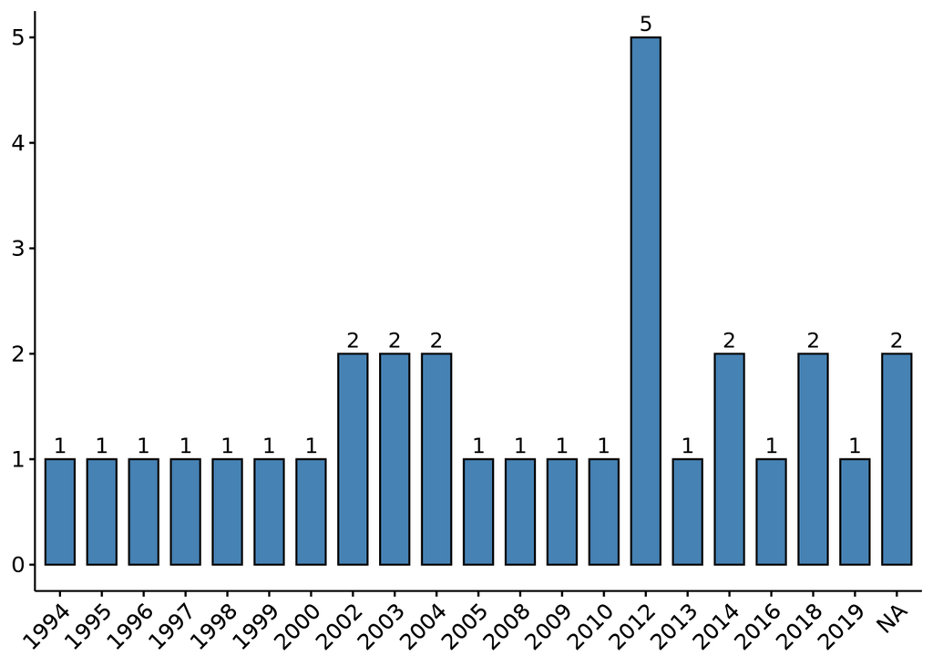

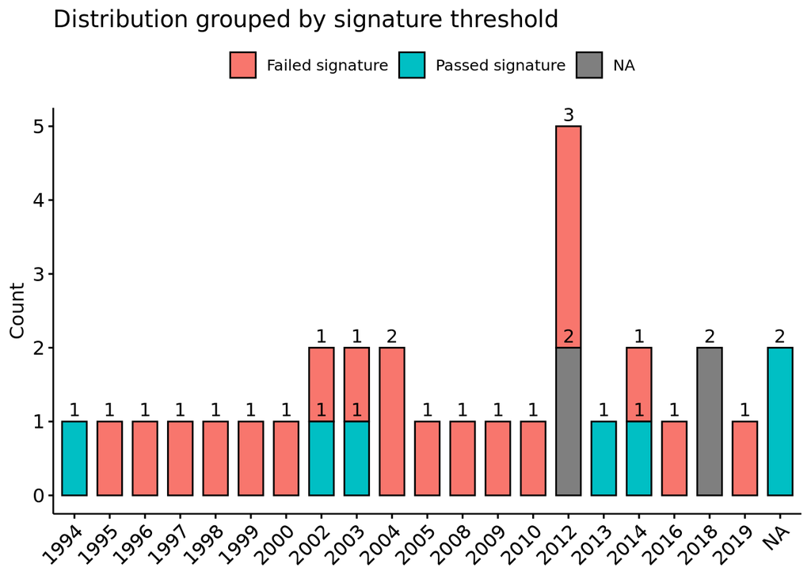

## 3.2 Table: Distribution of topics

**CLICK TO SEE RESULTS**

All initiatives (both Passed & Failed the signature thresholds)

| Topic | n | Percent |
| --- | --- | --- |
| Political / Electoral System | 18 | 58.1 |
| Mulitple topics | 4 | 12.9 |
| Interior Policies | 3 | 9.7 |
| Economy | 2 | 6.5 |
| Environment | 2 | 6.5 |
| Foreign affairs | 1 | 3.2 |
| Labour & Social | 1 | 3.2 |

Only initiatives that Passed the signature threshold

| Topic | n | Percent |
| --- | --- | --- |
| Political / Electoral System | 3 | 42.9 |
| Economy | 1 | 14.3 |
| Foreign affairs | 1 | 14.3 |
| Interior Policies | 1 | 14.3 |
| Mulitple topics | 1 | 14.3 |

Comparing Topics based on Signature Threshold

| Topic | Failed signature | Passed signature |
| --- | --- | --- |
| Economy | 1 | 1 |
| Environment | 2 | NA |
| Foreign affairs | NA | 1 |
| Interior Policies | 2 | 1 |
| Labour & Social | 1 | NA |
| Mulitple topics | 3 | 1 |
| Political / Electoral System | 11 | 3 |

## 3.3 Table: Signature threshold

**CLICK TO SEE RESULTS**

| Signature threshold | n | Percent |
| --- | --- | --- |
| Failed signature | 20 | 74.1 |
| Passed signature | 7 | 25.9 |

## 3.4 Table: Admissibility (failed + passed signature threshold)

**CLICK TO SEE RESULTS**

| Admissible | n | Percent |
| --- | --- | --- |
| Admissible | 26 | 96.3 |
| Inadmissible | 1 | 3.7 |

## 3.5 Table: Admissibility (passed signature threshold)

**CLICK TO SEE RESULTS**

| Admissible | n | Percent |
| --- | --- | --- |
| Admissible | 6 | 85.7 |
| Inadmissible | 1 | 14.3 |

## 3.6 Table: Referendum outcome (only includes initiatives where a vote took place)

**CLICK TO SEE RESULTS**

| Referendum_outcome | n | Percent |
| --- | --- | --- |
| failed | 3 | 100 |

# 4 QCA-like Case Summary

> **N.B.** This data in the table is completely fictitious. After the case has been analysed properly, it will be possible to construct a simplified model with the most important variables -probably with many more variables, which will have more varied values.

**CLICK TO SEE RESULTS**

| Variable | Value |
| --- | --- |
| Timing | PreTest |
| Institutional independence | Low |
| Practice | Medium |
| Formal limits | Low |
| Substantive limits | High |
| Rejection Rate | High |

# 5 Annex: Data collection process

# 6 Annex: References and links